# Exploratory Data Analysis

```python
#import libraries
import pandas as pd
import matplotlib.pyplot as plt
import numpy as np

from collections import Counter
```

```python
#import data
df = pd.read_csv('C:\\Users\Scoldingatom\Downloads\Steam Games.csv')
df
```

|  | AppID | Name | Release date | Estimated owners | Peak CCU | Required age | Price | DLC count | About the game | Supported languages | ... | Average playtime two weeks | Median playtime forever | Median playtime two weeks | Developers | Publishers | Categories | Genres | Tags | Screenshots | Movies |
| --- | --- | --- | --- | --- | --- | --- | --- | --- | --- | --- | --- | --- | --- | --- | --- | --- | --- | --- | --- | --- | --- |
| 0 | 20200 | Galactic Bowling | Oct 21, 2008 | 0 - 20000 | 0 | 0 | 19.99 | 0 | Galactic Bowling is an exaggerated and stylize... | ['English'] | ... | 0 | 0 | 0 | Perpetual FX Creative | Perpetual FX Creative | Single-player,Multi-player,Steam Achievements,... | Casual,Indie,Sports | Indie,Casual,Sports,Bowling | https://cdn.akamai.steamstatic.com/steam/apps/... | http://cdn.akamai.steamstatic.com/steam/apps/2... |
| 1 | 655370 | Train Bandit | Oct 12, 2017 | 0 - 20000 | 0 | 0 | 0.99 | 0 | THE LAW!! Looks to be a showdown atop a train.... | ['English', 'French', 'Italian', 'German', 'Sp... | ... | 0 | 0 | 0 | Rusty Moyher | Wild Rooster | Single-player,Steam Achievements,Full controll... | Action,Indie | Indie,Action,Pixel Graphics,2D,Retro,Arcade,Sc... | https://cdn.akamai.steamstatic.com/steam/apps/... | http://cdn.akamai.steamstatic.com/steam/apps/2... |
| 2 | 1732930 | Jolt Project | Nov 17, 2021 | 0 - 20000 | 0 | 0 | 4.99 | 0 | Jolt Project: The army now has a new robotics ... | ['English', 'Portuguese - Brazil'] | ... | 0 | 0 | 0 | Campião Games | Campião Games | Single-player | Action,Adventure,Indie,Strategy | NaN | https://cdn.akamai.steamstatic.com/steam/apps/... | http://cdn.akamai.steamstatic.com/steam/apps/2... |
| 3 | 1355720 | Henosis™ | Jul 23, 2020 | 0 - 20000 | 0 | 0 | 5.99 | 0 | HENOSIS™ is a mysterious 2D Platform Puzzler w... | ['English', 'French', 'Italian', 'German', 'Sp... | ... | 0 | 0 | 0 | Odd Critter Games | Odd Critter Games | Single-player,Full controller support | Adventure,Casual,Indie | 2D Platformer,Atmospheric,Surreal,Mystery,Puzz... | https://cdn.akamai.steamstatic.com/steam/apps/... | http://cdn.akamai.steamstatic.com/steam/apps/2... |
| 4 | 1139950 | Two Weeks in Painland | Feb 3, 2020 | 0 - 20000 | 0 | 0 | 0.00 | 0 | ABOUT THE GAME Play as a hacker who has arrang... | ['English', 'Spanish - Spain'] | ... | 0 | 0 | 0 | Unusual Games | Unusual Games | Single-player,Steam Achievements | Adventure,Indie | Indie,Adventure,Nudity,Violent,Sexual Content,... | https://cdn.akamai.steamstatic.com/steam/apps/... | http://cdn.akamai.steamstatic.com/steam/apps/2... |
| ... | ... | ... | ... | ... | ... | ... | ... | ... | ... | ... | ... | ... | ... | ... | ... | ... | ... | ... | ... | ... | ... |
| 85098 | 2669080 | Mannerheim's Saloon Car | Jan 2, 2024 | 0 - 0 | 0 | 0 | 0.00 | 0 | Marshal Mannerheim’s Saloon Car is the train c... | ['English', 'Finnish'] | ... | 0 | 0 | 0 | Xamk Game Studios | Sodan ja rauhan keskus Muisti, Päämajamuseo | Single-player,Tracked Controller Support,VR Only | Adventure,Simulation | NaN | https://cdn.akamai.steamstatic.com/steam/apps/... | http://cdn.akamai.steamstatic.com/steam/apps/2... |
| 85099 | 2736910 | Beer Run | Jan 3, 2024 | 0 - 0 | 0 | 0 | 0.00 | 0 | Beer Run is an Indie game created to steal bee... | ['English'] | ... | 0 | 0 | 0 | 955 Games | 955 Games | Single-player | Casual,Indie | NaN | https://cdn.akamai.steamstatic.com/steam/apps/... | http://cdn.akamai.steamstatic.com/steam/apps/2... |
| 85100 | 2743220 | My Friend The Spider | Jan 4, 2024 | 0 - 0 | 0 | 0 | 0.00 | 0 | A small 'horror' narrative game about isolatio... | ['English'] | ... | 0 | 0 | 0 | MCA | MCA | Single-player | Adventure,Simulation | NaN | https://cdn.akamai.steamstatic.com/steam/apps/... | http://cdn.akamai.steamstatic.com/steam/apps/2... |
| 85101 | 2293130 | Path of Survivors | Jan 8, 2024 | 0 - 0 | 0 | 0 | 3.99 | 0 | Path of Survivors is a multi-class auto-battle... | ['English'] | ... | 0 | 0 | 0 | Limited Input | Limited Input | Single-player,Steam Achievements,Partial Contr... | Action,Casual,Indie,RPG,Simulation | NaN | https://cdn.akamai.steamstatic.com/steam/apps/... | http://cdn.akamai.steamstatic.com/steam/apps/2... |
| 85102 | 2738840 | The Night Heist | Jan 5, 2024 | 0 - 0 | 0 | 0 | 9.99 | 0 | Meet Mariah, Maria, and Missy a group of colle... | ['English'] | ... | 0 | 0 | 0 | Ladell Parks | Ladell Parks | Single-player,Steam Achievements,Full controll... | Casual,Indie | NaN | https://cdn.akamai.steamstatic.com/steam/apps/... | http://cdn.akamai.steamstatic.com/steam/apps/2... |

85103 rows × 39 columns

```python
df.shape
```

```
(85103, 39)
```

```python
# Display max columns
pd.set_option('display.max_columns', 39)
df.head()
```

|  | AppID | Name | Release date | Estimated owners | Peak CCU | Required age | Price | DLC count | About the game | Supported languages | Full audio languages | Reviews | Header image | Website | Support url | Support email | Windows | Mac | Linux | Metacritic score | Metacritic url | User score | Positive | Negative | Score rank | Achievements | Recommendations | Notes | Average playtime forever | … |
| --- | --- | --- | --- | --- | --- | --- | --- | --- | --- | --- | --- | --- | --- | --- | --- | --- | --- | --- | --- | --- | --- | --- | --- | --- | --- | --- | --- | --- | --- | --- |
| 0 | 20200 | Galactic Bowling | Oct 21, 2008 | 0 - 20000 | 0 | 0 | 19.99 | 0 | Galactic Bowling is an exaggerated and stylize... | ['English'] | [] | NaN | https://cdn.akamai.steamstatic.com/steam/apps/... | http://www.galacticbowling.net | NaN | NaN | True | False | False | 0 | NaN | 0 | 6 | 11 | NaN | 30 | 0 | NaN | 0 | … |
| 1 | 655370 | Train Bandit | Oct 12, 2017 | 0 - 20000 | 0 | 0 | 0.99 | 0 | THE LAW!! Looks to be a showdown atop a train.... | ['English', 'French', 'Italian', 'German', 'Sp... | [] | NaN | https://cdn.akamai.steamstatic.com/steam/apps/... | http://trainbandit.com | NaN | support@rustymoyher.com | True | True | False | 0 | NaN | 0 | 53 | 5 | NaN | 12 | 0 | NaN | 0 | … |
| 2 | 1732930 | Jolt Project | Nov 17, 2021 | 0 - 20000 | 0 | 0 | 4.99 | 0 | Jolt Project: The army now has a new robotics ... | ['English', 'Portuguese - Brazil'] | [] | NaN | https://cdn.akamai.steamstatic.com/steam/apps/... | NaN | NaN | ramoncampiaof31@gmail.com | True | False | False | 0 | NaN | 0 | 0 | 0 | NaN | 0 | 0 | NaN | 0 | … |
| 3 | 1355720 | Henosis™ | Jul 23, 2020 | 0 - 20000 | 0 | 0 | 5.99 | 0 | HENOSIS™ is a mysterious 2D Platform Puzzler w... | ['English', 'French', 'Italian', 'German', 'Sp... | [] | NaN | https://cdn.akamai.steamstatic.com/steam/apps/... | https://henosisgame.com/ | https://henosisgame.com/ | info@henosisgame.com | True | True | True | 0 | NaN | 0 | 3 | 0 | NaN | 0 | 0 | NaN | 0 | … |
| 4 | 1139950 | Two Weeks in Painland | Feb 3, 2020 | 0 - 20000 | 0 | 0 | 0.00 | 0 | ABOUT THE GAME Play as a hacker who has arrang... | ['English', 'Spanish - Spain'] | [] | NaN | https://cdn.akamai.steamstatic.com/steam/apps/... | https://www.unusual-games.com/home/ | https://www.unusual-games.com/contact/ | welistentoyou@unusual-games.com | True | True | False | 0 | NaN | 0 | 50 | 8 | NaN | 17 | 0 | This Game may contain content not appropriate ... | 0 | … |

```python
df.dtypes
```

```
AppID                           int64
Name                           object
Release date                   object
Estimated owners               object
Peak CCU                        int64
Required age                    int64
Price                         float64
DLC count                       int64
About the game                 object
Supported languages            object
Full audio languages           object
Reviews                        object
Header image                   object
Website                        object
Support url                    object
Support email                  object
Windows                          bool
Mac                              bool
Linux                            bool
Metacritic score                int64
Metacritic url                 object
User score                      int64
Positive                        int64
Negative                        int64
Score rank                    float64
Achievements                    int64
Recommendations                 int64
Notes                          object
Average playtime forever        int64
Average playtime two weeks      int64
Median playtime forever         int64
Median playtime two weeks       int64
Developers                     object
Publishers                     object
Categories                     object
Genres                         object
Tags                           object
Screenshots                    object
Movies                         object
dtype: object
```

```python
# Keeping relevant columns only
variables_to_keep = ['AppID','Name','Release date','Estimated owners','Peak CCU','Price','DLC count','About the game','Supported languages',
                     'Full audio languages','Windows','Mac','Linux','Metacritic score','Positive','Negative',
                     'Achievements','Average playtime forever','Average playtime two weeks','Developers','Publishers','Categories','Genres','Tags']
game_data = df[variables_to_keep]
```

```python
# Examine few rows of data and its shape
game_data
```

|  | AppID | Name | Release date | Estimated owners | Peak CCU | Price | DLC count | About the game | Supported languages | Full audio languages | Windows | Mac | Linux | Metacritic score | Positive | Negative | Achievements | Average playtime forever | Average playtime two weeks | Developers | Publishers | Categories | Genres | Tags |
| --- | --- | --- | --- | --- | --- | --- | --- | --- | --- | --- | --- | --- | --- | --- | --- | --- | --- | --- | --- | --- | --- | --- | --- | --- |
| 0 | 20200 | Galactic Bowling | Oct 21, 2008 | 0 - 20000 | 0 | 19.99 | 0 | Galactic Bowling is an exaggerated and stylize... | ['English'] | [] | True | False | False | 0 | 6 | 11 | 30 | 0 | 0 | Perpetual FX Creative | Perpetual FX Creative | Single-player,Multi-player,Steam Achievements,... | Casual,Indie,Sports | Indie,Casual,Sports,Bowling |
| 1 | 655370 | Train Bandit | Oct 12, 2017 | 0 - 20000 | 0 | 0.99 | 0 | THE LAW!! Looks to be a showdown atop a train.... | ['English', 'French', 'Italian', 'German', 'Sp... | [] | True | True | False | 0 | 53 | 5 | 12 | 0 | 0 | Rusty Moyher | Wild Rooster | Single-player,Steam Achievements,Full controll... | Action,Indie | Indie,Action,Pixel Graphics,2D,Retro,Arcade,Sc... |
| 2 | 1732930 | Jolt Project | Nov 17, 2021 | 0 - 20000 | 0 | 4.99 | 0 | Jolt Project: The army now has a new robotics ... | ['English', 'Portuguese - Brazil'] | [] | True | False | False | 0 | 0 | 0 | 0 | 0 | 0 | Campião Games | Campião Games | Single-player | Action,Adventure,Indie,Strategy | NaN |
| 3 | 1355720 | Henosis™ | Jul 23, 2020 | 0 - 20000 | 0 | 5.99 | 0 | HENOSIS™ is a mysterious 2D Platform Puzzler w... | ['English', 'French', 'Italian', 'German', 'Sp... | [] | True | True | True | 0 | 3 | 0 | 0 | 0 | 0 | Odd Critter Games | Odd Critter Games | Single-player,Full controller support | Adventure,Casual,Indie | 2D Platformer,Atmospheric,Surreal,Mystery,Puzz... |
| 4 | 1139950 | Two Weeks in Painland | Feb 3, 2020 | 0 - 20000 | 0 | 0.00 | 0 | ABOUT THE GAME Play as a hacker who has arrang... | ['English', 'Spanish - Spain'] | [] | True | True | False | 0 | 50 | 8 | 17 | 0 | 0 | Unusual Games | Unusual Games | Single-player,Steam Achievements | Adventure,Indie | Indie,Adventure,Nudity,Violent,Sexual Content,... |
| ... | ... | ... | ... | ... | ... | ... | ... | ... | ... | ... | ... | ... | ... | ... | ... | ... | ... | ... | ... | ... | ... | ... | ... | ... |
| 85098 | 2669080 | Mannerheim's Saloon Car | Jan 2, 2024 | 0 - 0 | 0 | 0.00 | 0 | Marshal Mannerheim’s Saloon Car is the train c... | ['English', 'Finnish'] | ['Finnish'] | True | False | False | 0 | 0 | 0 | 0 | 0 | 0 | Xamk Game Studios | Sodan ja rauhan keskus Muisti, Päämajamuseo | Single-player,Tracked Controller Support,VR Only | Adventure,Simulation | NaN |
| 85099 | 2736910 | Beer Run | Jan 3, 2024 | 0 - 0 | 0 | 0.00 | 0 | Beer Run is an Indie game created to steal bee... | ['English'] | [] | True | False | False | 0 | 0 | 0 | 0 | 0 | 0 | 955 Games | 955 Games | Single-player | Casual,Indie | NaN |
| 85100 | 2743220 | My Friend The Spider | Jan 4, 2024 | 0 - 0 | 0 | 0.00 | 0 | A small 'horror' narrative game about isolatio... | ['English'] | ['English'] | True | False | False | 0 | 0 | 0 | 0 | 0 | 0 | MCA | MCA | Single-player | Adventure,Simulation | NaN |
| 85101 | 2293130 | Path of Survivors | Jan 8, 2024 | 0 - 0 | 0 | 3.99 | 0 | Path of Survivors is a multi-class auto-battle... | ['English'] | [] | True | False | False | 0 | 0 | 0 | 34 | 0 | 0 | Limited Input | Limited Input | Single-player,Steam Achievements,Partial Contr... | Action,Casual,Indie,RPG,Simulation | NaN |
| 85102 | 2738840 | The Night Heist | Jan 5, 2024 | 0 - 0 | 0 | 9.99 | 0 | Meet Mariah, Maria, and Missy a group of colle... | ['English'] | ['English'] | True | False | False | 0 | 0 | 0 | 12 | 0 | 0 | Ladell Parks | Ladell Parks | Single-player,Steam Achievements,Full controll... | Casual,Indie | NaN |

85103 rows × 24 columns

```python
#Check for missing values
game_data.isnull().sum()
```

```
AppID                             0
Name                              6
Release date                      0
Estimated owners                  0
Peak CCU                          0
Price                             0
DLC count                         0
About the game                 3567
Supported languages               0
Full audio languages              0
Windows                           0
Mac                               0
Linux                             0
Metacritic score                  0
Positive                          0
Negative                          0
Achievements                      0
Average playtime forever          0
Average playtime two weeks        0
Developers                     3587
Publishers                     3867
Categories                     4598
Genres                         3555
Tags                          21100
dtype: int64
```

```python
# Check for duplicates
game_data['AppID'].duplicated().sum()
```

```
0
```

```python
# Convert 'release_date' to datetime
game_data['Release date'] = pd.to_datetime(game_data['Release date'], format='mixed')
```

```python
#earliest title released
game_data['Release date'].min()
```

```
Timestamp('1997-06-30 00:00:00')
```

```python
#latest title released
game_data['Release date'].max()
```

```
Timestamp('2025-04-14 00:00:00')
```

```python
# Found a game released in the future so i want to find any more
from datetime import datetime

today = datetime.now()

future_games = game_data['Release date'] > today

# Using the mask to filter rows
future_dates = game_data.loc[future_games]

print(future_dates)
```

```
         AppID  Name Release date Estimated owners  Peak CCU  Price  \
66999  2022640  XTAL   2025-04-14            0 - 0         0    0.0

       DLC count                                     About the game  \
66999          0  A distant past echoes through planet Syro, whi...

      Supported languages Full audio languages  Windows    Mac  Linux  \
66999         ['English']          ['English']     True  False  False

       Metacritic score  Positive  Negative  Achievements  \
66999                 0         0         0             0

       Average playtime forever  Average playtime two weeks   Developers  \
66999                         0                           0  True Colors

        Publishers                                         Categories  \
66999  True Colors  Single-player,Steam Achievements,Full controll...

                 Genres Tags
66999  Action,Adventure  NaN
```

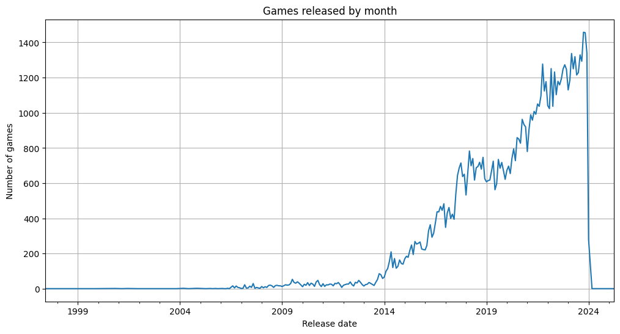

```python
# Number of games released by month
plt.figure(figsize=(12, 6))
game_data.groupby(game_data['Release date'].dt.to_period('M')).size().plot(kind='line')
plt.title('Games released by month')
plt.ylabel('Number of games')
plt.grid(True)
plt.show()
```

# Price Analysis

A majority (95%) of games are priced between 0 and 20. 19% of all games are free on Steam.

There is one game priced at nearly 1000. We'll be removing this outlier.

Only 65 games are priced over 150. We'll be removing these.

```python
bins = range(0, 121, 20)

# Categorizing price into bins
game_data['Price Bin'] = pd.cut(game_data['Price'], bins=bins, right=False, include_lowest=True)

# Count the number of games in each price bin
price_distribution = game_data['Price Bin'].value_counts(normalize=True).sort_index()
print(price_distribution)
```

```
Price Bin
[0, 20)       0.951396
[20, 40)      0.038323
[40, 60)      0.007987
[60, 80)      0.001376
[80, 100)     0.000494
[100, 120)    0.000423
Name: proportion, dtype: float64
```

```python
# Number of free games
free_games = (game_data['Price'] == 0)

number_of_free_games = free_games.sum()
print("Number of free games:", number_of_free_games)
number_of_free_games = free_games.sum()
print("Proportion of free games:", number_of_free_games/game_data.shape[0])

# About 19% are free games
```

```
Number of free games: 16461
Proportion of free games: 0.1934244386214352
```

```python
# Highest prices game
game_data['Price'].max()
```

```
999.98
```

```python
# Games over 150
games_over_100 = (game_data['Price'] > 150)

how_many = games_over_100.sum()
print("Number of games over 150:", how_many)
```

```
Number of games over 150: 65
```

## DLC analysis

Majority of games never add any DLCs

It is a tiny percentage that have 2 or more DLCs.

Surprisingly, the highest DLC count was 2366.

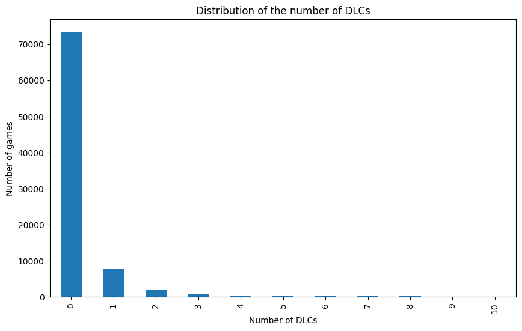

```python
# Number of DLCs (up to 10)
dlc_counts = game_data['DLC count'].value_counts().sort_index()
dlc_counts = dlc_counts[dlc_counts.index <= 10]
plt.figure(figsize=(10, 6))
dlc_counts.plot(kind='bar')
plt.title('Distribution of the number of DLCs')
plt.xlabel('Number of DLCs')
plt.ylabel('Number of games')
plt.show()
```

```python
# Maximum number of DLCs
game_data['DLC count'].max()
```

```
2366
```

## Platform

To no suprise, windows dominates the market as the most used operating system.

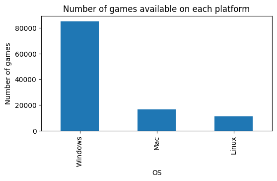

```python
# What platform do gamers game on?

platform_sums = game_data[['Windows', 'Mac', 'Linux']].sum()
plt.figure(figsize=(6, 3))
platform_sums.plot(kind='bar')
plt.title('Number of games available on each platform')
plt.xlabel('OS')
plt.ylabel('Number of games')
plt.show()
```

## Languages Analysis

```python
import ast

#This function will convert strings into actual Python object it represents -- here I need strings to lists
def parse_languages(languages_str):
    try:
        return ast.literal_eval(languages_str)
    except Exception as e:
        # Print the problematic string and the error for debugging
        print(f"Error parsing: {languages_str}")
        print(f"Error: {e}")
        return []  # Return an empty list in case of an error
```

```python
# Apply this function to each row in the 'supported_languages' column
game_data['Supported languages'] = game_data['Supported languages'].apply(parse_languages)

# Flatten the list of supported languages
all_languages = [lang for sublist in game_data['Supported languages'] for lang in sublist]

# Count occurrences of each language
language_counts = Counter(all_languages)

# dictionary into dataframe to easily visualize
lang_df = pd.DataFrame.from_dict(language_counts, orient='index', columns=['Count'])
lang_df.sort_values('Count', ascending=False, inplace=True)
```

[output not shown]

[output cut: 692 more lines]

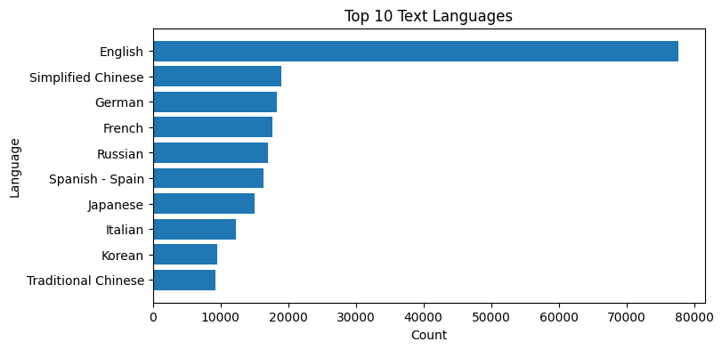

```python
# Take the top 10
top_lang_df = lang_df.head(10)

plt.figure(figsize=(8, 4))
plt.barh(top_lang_df.index, top_lang_df['Count'])
plt.title('Top 10 Text Languages')
plt.xlabel('Count')
plt.ylabel('Language')
plt.gca().invert_yaxis()
plt.show()
```

## Review Analysis

One-fourth of all games do not have any reviews. These serve as useless.

```python
# Proportion of games with no reviews
round(game_data[(game_data['Positive'] + game_data['Negative']) == 0].shape[0] / game_data.shape[0], 2)
```

```
0.25
```

## Estimated Owners / Units Sold

I will remove games with 0 - 0 estimated owners. That means nobody bought the game.

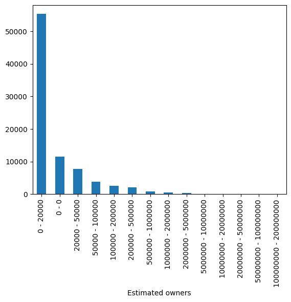

```python
# Estimated owners distribution
game_data['Estimated owners'].value_counts().plot(kind='bar')
```

## Playtime

A big majority of players play on average under 2000 minutes of playtime alltime for a game.

82% of games have 0 playtime

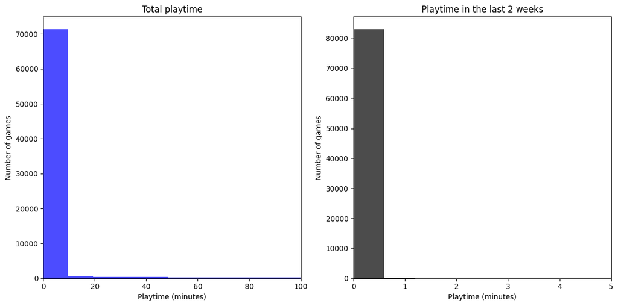

```python
# Average playtime
plt.figure(figsize=(12, 6))
plt.subplot(1, 2, 1)


plt.hist(game_data['Average playtime forever'], bins=15000, color='blue', alpha=0.7)
plt.title('Total playtime')
plt.xlabel('Playtime (minutes)')
plt.ylabel('Number of games')
plt.xlim(0, 100)
plt.subplot(1, 2, 2)

plt.hist(game_data['Average playtime two weeks'], bins=32000, color='black', alpha=0.7)
plt.title('Playtime in the last 2 weeks')
plt.xlabel('Playtime (minutes)')
plt.ylabel('Number of games')
plt.xlim(0, 5)
plt.tight_layout()
plt.show()
```

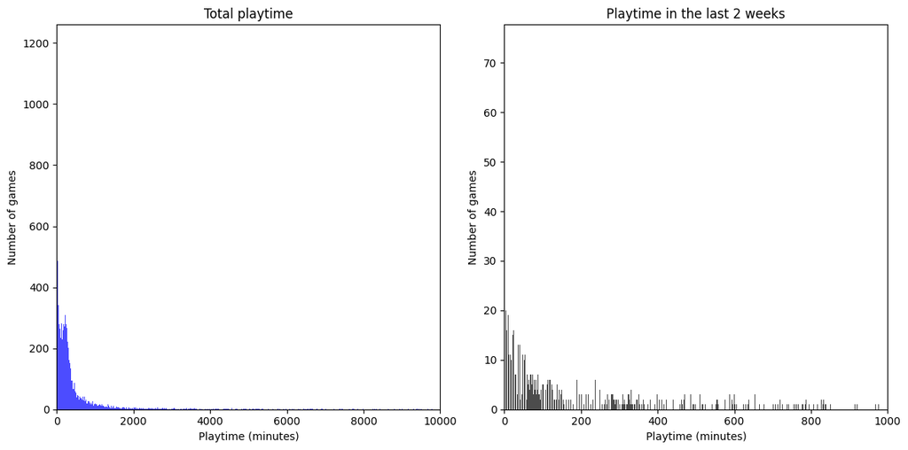

```python
# Average playtime
plt.figure(figsize=(12, 6))
plt.subplot(1, 2, 1)

playtime_forever_df = game_data[game_data['Average playtime forever'] != 0]

plt.hist(playtime_forever_df['Average playtime forever'], bins=15000, color='blue', alpha=0.7)
plt.title('Total playtime')
plt.xlabel('Playtime (minutes)')
plt.ylabel('Number of games')
plt.xlim(0, 10000)
plt.subplot(1, 2, 2)

playtime_2weeks_df = game_data[game_data['Average playtime two weeks'] != 0]

plt.hist(playtime_2weeks_df['Average playtime two weeks'], bins=32000, color='black', alpha=0.7)
plt.title('Playtime in the last 2 weeks')
plt.xlabel('Playtime (minutes)')
plt.ylabel('Number of games')
plt.xlim(0, 1000)
plt.tight_layout()
plt.show()
```

```python
# Proportion of games without playtime data
proportion = game_data[game_data['Average playtime forever'] == 0].shape[0] / game_data.shape[0]
round(proportion, 2)

print(proportion)
```

```
0.8247887853542178
```

## Categories, Genres, Tags Analysis

Single-player category is the most popular game. A lot of games also have Steam Achievements

Indie, Casual, and Action are most popular genres.

Indie, Singleplayer, and Action are most popular tags. Tags are what gamers categorize games.

[figure not shown]

```python
#Splitting categories on the commas since categories is comma-separated string
if isinstance(game_data['Categories'].iloc[0], str):
    game_data['Categories'] = game_data['Categories'].dropna().apply(lambda x: x.split(','))

# Flatten the list of categories
categories = [category.strip() for sublist in game_data['Categories'].dropna() for category in sublist]

# Count occurrences
category_counts = Counter(categories)

# Prepare data for plotting
top_categories = pd.DataFrame(category_counts.most_common(10), columns=['Category', 'Games'])

# Plot
plt.figure(figsize=(5, 5))
plt.barh(top_categories['Category'], top_categories['Games'])
plt.title('Top 10 Categories by Number of Games')
plt.xlabel('Number of Games')
plt.ylabel('Category')
plt.xticks(rotation=45)
plt.gca().invert_yaxis()
plt.yticks(fontsize=10)
plt.show()
```

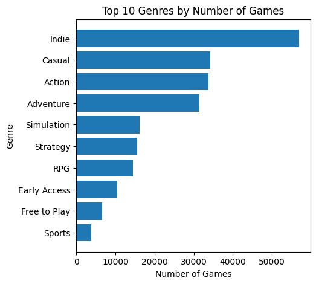

```python
#Splitting Genres on the commas since categories is comma-separated string
if isinstance(game_data['Genres'].iloc[0], str):
    game_data['Genres'] = game_data['Genres'].dropna().apply(lambda x: x.split(','))

# Flatten the list of genres
genres = [genre.strip() for sublist in game_data['Genres'].dropna() for genre in sublist]

# Count occurrences
genre_counts = Counter(genres)

# Prepare data for plotting
top_genres = pd.DataFrame(genre_counts.most_common(10), columns=['Genre', 'Games'])

# Plotting
plt.figure(figsize=(5, 5))
plt.barh(top_genres['Genre'], top_genres['Games'])
plt.title('Top 10 Genres by Number of Games')
plt.xlabel('Number of Games')
plt.ylabel('Genre')
plt.gca().invert_yaxis()
plt.yticks(fontsize=10)
plt.show()
```

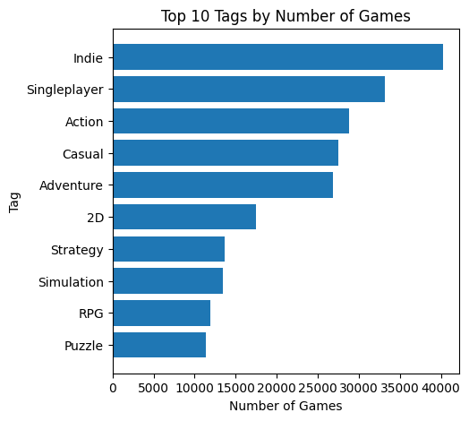

```python
#Splitting Tags on the commas since categories is comma-separated string
if isinstance(game_data['Tags'].iloc[0], str):
    game_data['Tags'] = game_data['Tags'].dropna().apply(lambda x: x.split(','))

# Flatten the list of tags
tags = [tag.strip() for sublist in game_data['Tags'].dropna() for tag in sublist]

# Count occurrences
tag_counts = Counter(tags)

# Prepare data for plotting
top_tags = pd.DataFrame(tag_counts.most_common(10), columns=['Tag', 'Games'])

# Plotting
plt.figure(figsize=(5, 5))
plt.barh(top_tags['Tag'], top_tags['Games'])
plt.title('Top 10 Tags by Number of Games')
plt.xlabel('Number of Games')
plt.ylabel('Tag')
plt.gca().invert_yaxis()
plt.yticks(fontsize=10)
plt.show()
```

```python
print(game_data['Developers'].head(20))
```

```
0      Perpetual FX Creative
1               Rusty Moyher
2              Campião Games
3          Odd Critter Games
4              Unusual Games
5                      7Road
6              MAKSIM VOLKAU
7                 magnussoft
8              Growing Seeds
9             ONE MORE LEVEL
10            Pixelated Milk
11    Wise Wizard Games, LLC
12            Beardlings LLC
13         Educational Games
14           Parange Project
15        Team17 Digital Ltd
16              SCS Software
17             Lonely Troops
18                  KENZsoft
19                  Necavare
Name: Developers, dtype: object
```

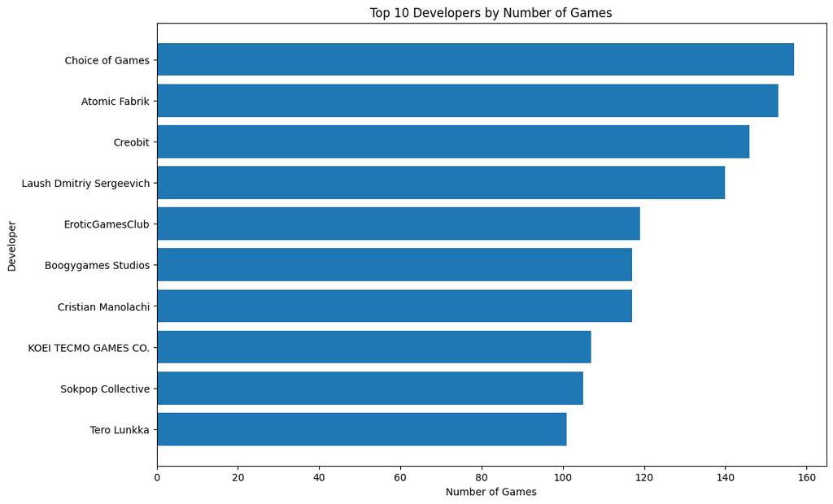

```python
import re

# Convert to list if necessary and not already handled
if isinstance(game_data['Developers'].iloc[0], str):
    game_data['Developers'] = game_data['Developers'].dropna().apply(lambda x: x.split(','))

# Regex pattern to remove legal business terms
pattern = r'\b(Inc|LLC|Ltd|LTD|Corp|GmbH|S\.A\.|S\.L\.|Corporation)\b\.?'

# Flatten the list of developers and remove common terms
developers = []
for sublist in game_data['Developers'].dropna():
    for dev in sublist:
        # Clean the developer name by removing legal terms using regex
        cleaned_dev = re.sub(pattern, '', dev).strip()
        developers.append(cleaned_dev)

# Count occurrences
developer_counts = Counter(developers)

# Prepare data for plotting
top_developers = pd.DataFrame(developer_counts.most_common()[1:11], columns=['Developer', 'Games'])

# Plotting
plt.figure(figsize=(12, 8))
plt.barh(top_developers['Developer'], top_developers['Games'])
plt.title('Top 10 Developers by Number of Games')
plt.xlabel('Number of Games')
plt.ylabel('Developer')
plt.gca().invert_yaxis()
plt.show()
```

```python
# Total number of developers
all_developers = [dev for sublist in game_data['Developers'].dropna() for dev in sublist]
len(set(all_developers))
```

```
52920
```

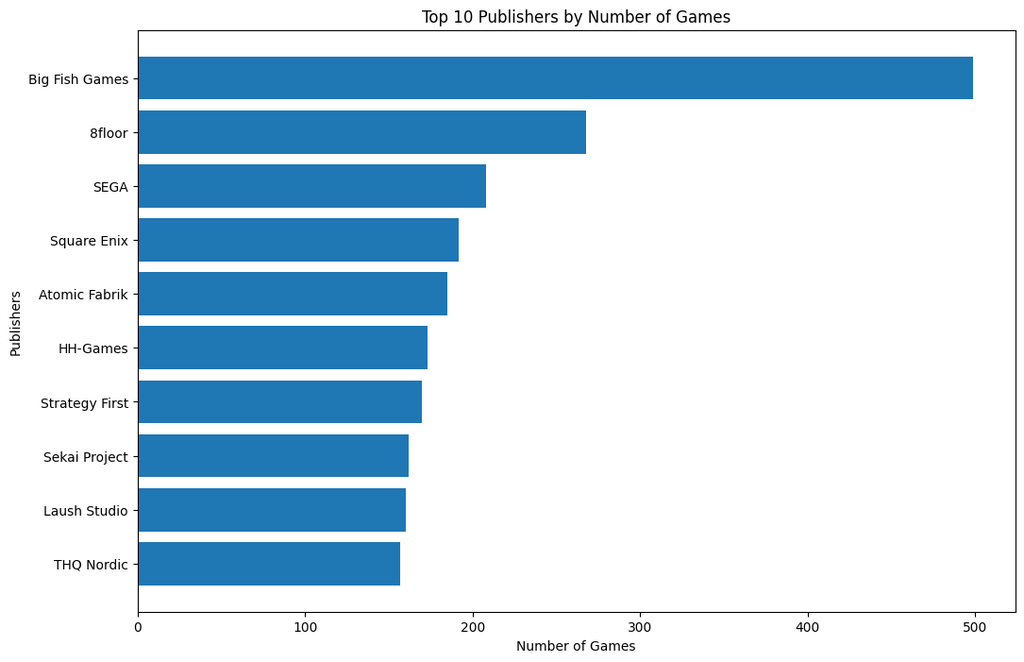

```python
# Convert to list if necessary and not already handled
if isinstance(game_data['Publishers'].iloc[0], str):
    game_data['Publishers'] = game_data['Publishers'].dropna().apply(lambda x: x.split(','))

# Regex pattern to remove legal business terms
pattern_for_publisher = r'\b(Inc|LLC|Ltd|LTD|Corp|GmbH|S\.A\.|S\.L\.|Corporation)\b\.?'

# Flatten the list of developers and remove common terms
publishers = []
for sublist in game_data['Publishers'].dropna():
    for dev in sublist:
        # Clean the developer name by removing legal terms using regex
        cleaned_devp = re.sub(pattern_for_publisher, '', dev).strip()
        publishers.append(cleaned_devp)

# Count occurrences
publisher_counts = Counter(publishers)

# Prepare data for plotting
top_publishers = pd.DataFrame(publisher_counts.most_common()[1:11], columns=['Publishers', 'Games'])

# Plotting
plt.figure(figsize=(12, 8))
plt.barh(top_publishers['Publishers'], top_publishers['Games'])
plt.title('Top 10 Publishers by Number of Games')
plt.xlabel('Number of Games')
plt.ylabel('Publishers')
plt.gca().invert_yaxis()
plt.show()
```

# Data Transformation - Cleaning

```python
# Make a copy of dateframe
new_game_data = game_data.copy()
```

```python
#Removing games with no estimated owners
new_game_data = new_game_data[(new_game_data['Estimated owners'] != "0 - 0")]
```

```python
# Games released before 2010 were very few.

new_game_data['Release date'] = pd.to_datetime(new_game_data['Release date'], format='mixed')
new_game_data = new_game_data[(new_game_data['Release date'].dt.year >= 2010)]
```

```python
#remove future dated game
new_game_data = new_game_data[new_game_data['AppID'] != 2022640]
```

```python
# Remove priced above 150$
new_game_data = new_game_data[(new_game_data['Price'] < 150)]
```

```python
#Removing Zero reviewed games since it doesnt tell us much
new_game_data = new_game_data[(new_game_data['Positive'] + new_game_data['Negative'] != 0)]
```

```python
#If game does not have categories then it serves little value
new_game_data = new_game_data[(new_game_data['Categories'].str.len() != 0)]
new_game_data = new_game_data.dropna(subset=['Categories'])
```

```python
# Split estimated_owners into two: min_owners and max_owners
new_game_data[['Min owners', 'Max owners']] = new_game_data['Estimated owners'].str.split(' - ', expand=True)

new_game_data[['Min owners', 'Max owners']]
```

|  | Min owners | Max owners |
| --- | --- | --- |
| 1 | 0 | 20000 |
| 3 | 0 | 20000 |
| 4 | 0 | 20000 |
| 5 | 50000 | 100000 |
| 6 | 0 | 20000 |
| ... | ... | ... |
| 85077 | 0 | 20000 |
| 85079 | 0 | 20000 |
| 85083 | 0 | 20000 |
| 85085 | 0 | 20000 |
| 85094 | 0 | 20000 |

62282 rows × 2 columns

```python
new_game_data.shape
```

```
(62282, 27)
```

```python
new_game_data.isnull().sum()
```

```
AppID                           0
Name                            0
Release date                    0
Estimated owners                0
Peak CCU                        0
Price                           0
DLC count                       0
About the game                 78
Supported languages             0
Full audio languages            0
Windows                         0
Mac                             0
Linux                           0
Metacritic score                0
Positive                        0
Negative                        0
Achievements                    0
Average playtime forever        0
Average playtime two weeks      0
Developers                      3
Publishers                    292
Categories                      0
Genres                         55
Tags                            5
Price Bin                       4
Min owners                      0
Max owners                      0
dtype: int64
```

### Tranform into tables so its easier for Tableau

```python
#making a copy of transformed dataframe
df2 = new_game_data.copy()
```

```python
# Calculate the every occurence of tags, supported languages, genres, and categories for each title
df2['tag_count'] = df2['Tags'].apply(lambda x: len(x) if isinstance(x, list) else 0)
df2['Language_count'] = df2['Supported languages'].apply(lambda x: len(x) if isinstance(x, list) else 0)
df2['Genre_count'] = df2['Genres'].apply(lambda x: len(x) if isinstance(x, list) else 0)
df2['Category_count'] = df2['Categories'].apply(lambda x: len(x) if isinstance(x, list) else 0)

# Display the updated DataFrame
print(df2[['Tags', 'tag_count','Supported languages','Language_count','Genres','Genre_count','Categories','Category_count']])
```

```
                                                    Tags  tag_count  \
1      [Indie, Action, Pixel Graphics, 2D, Retro, Arc...         20
3      [2D Platformer, Atmospheric, Surreal, Mystery,...         19
4      [Indie, Adventure, Nudity, Violent, Sexual Con...          6
5      [Turn-Based Combat, Massively Multiplayer, Mul...         20
6      [Tower Defense, Rogue-lite, RTS, Replay Value,...         20
...                                                  ...        ...
85077  [Simulation, Casual, Sandbox, Farming Sim, Lif...         18
85079  [Casual, Adventure, Point & Click, Exploration...         16
85083  [Casual, Sexual Content, Nudity, Adventure, Ma...         19
85085  [Adventure, Action-Adventure, Exploration, FPS...         15
85094  [Casual, Tower Defense, Time Management, 3D, C...         18

                                     Supported languages  Language_count  \
1      [English, French, Italian, German, Spanish - S...              10
```

[output cut: 38 more lines]

```python
# Explode 'Tags' and keep 'tag_count' aligned with each tag
tags_df = df2[['AppID', 'Tags', 'tag_count']].explode('Tags')
tags_df = tags_df.rename(columns={'Tags': 'Tag'})

# Explode 'Categories'
categories_df = df2[['AppID', 'Categories','Category_count']].explode('Categories')
categories_df = categories_df.rename(columns={'Categories': 'Category'})

# Explode 'Genres'
genres_df = df2[['AppID', 'Genres','Genre_count']].explode('Genres')
genres_df = genres_df.rename(columns={'Genres': 'Genre'})

# Explode 'Supported languages' and keep 'Language_count' aligned with each tag
languages_df = df2[['AppID', 'Supported languages','Language_count']].explode('Supported languages')
languages_df = languages_df.rename(columns={'Supported languages': 'Supported language'})

# Remove the list columns from the main DataFrame
notwanted = ['Categories', 'Tags', 'tag_count', 'Supported languages','Language_count','Genres','Genre_count','Categories','Category_count']
final_data = df2.drop(columns=notwanted)
```

```python
final_data.to_csv('C:\\Users\Scoldingatom\Downloads\GameData.csv', index=False)
categories_df.to_csv('C:\\Users\Scoldingatom\Downloads\GameCategory.csv', index=False)
genres_df.to_csv('C:\\Users\Scoldingatom\Downloads\GameGenre.csv', index=False)
tags_df.to_csv('C:\\Users\Scoldingatom\Downloads\GameTags.csv', index=False)
languages_df.to_csv('C:\\Users\Scoldingatom\Downloads\GameLang.csv', index=False)
```